# W1: 1st meeting & learning the arcane language

*First, let us introduce ourselves and what we hope to achieve.*

**Goals of the group:**

-learn publication-quality statistical analysis and visualization  
-friendly and open environment to increase fellowship  
-locally relevant  
-accessible for beginners & experts  
-teaching/service experience for the CV if you want to lead session(s)  
-others?

**Components of sessions:**

-expert-led lesson  
-unstructured period for work and collaborative help, “how do I…?”

**Lesson topics:**

*Week 2*  
-best practices for excel files, data management  
-data visualization with ggplot()  
–mean and SEM counts on different dates by one or more factors  
–summaries with bar charts or boxplots  
–subsetting parts of datafiles  
–others?

*Week 3*  
-Basic statistics, the “dark craft”  
–ANOVA, ANCOVA, linear model, t-test, tukey test, others?

*Future*

-High priority  
–visualization: creating and saving publication-quality figures with ggplot()  
–dark arts of statistics: generalized linear models with glmmTMB()

-Less priority  
–github for version control, data sharing, and reproducibility  
–if/then, while loops, and for loops

-lowest priorty  
–postmodern statistics: bayesian, PCA, structural equation models  
–databases like SQL  
–map stuff like GIS or similar functions  
–specific analyses like probit for LD50, mortality/survival

Let us begin. This code and associated files can be found in: https://github.com/robertorpet/raindrop

```r
#using R like a calculator
1 + 1
```

```
## [1] 2
```

```r
1+1
```

```
## [1] 2
```

```r
1                         +1
```

```
## [1] 2
```

```r
#storing things in variables
rob_variable <- 1 + 1 #notice use of "<-"
rob_variable
```

```
## [1] 2
```

```r
rob_variable <- rob_variable + 1
rob_othervariable = 2 + 2 #you can use "=" but that's not preferred
rob_othervariable
```

```
## [1] 4
```

```r
print("this is rob's variable")
```

```
## [1] "this is rob's variable"
```

```r
rob_variable
```

```
## [1] 3
```

```r
rob_variable == rob_othervariable # "==" is to check if it is equal
```

```
## [1] FALSE
```

```r
rob_variable = rob_othervariable
rob_variable
```

```
## [1] 4
```

```r
#operators for logic. These can be useful for subsetting data
1 > 2
```

```
## [1] FALSE
```

```r
1 == 2
```

```
## [1] FALSE
```

```r
1 < 2
```

```
## [1] TRUE
```

```r
1 != 2
```

```
## [1] TRUE
```

```r
# try 1 = 2 or 1 <- 2. you can't assign values to numerals, they are reserved.

#multiple numbers and basic statistics summary
#things that have "()" after them are "functions". Inside the () hit TAB to see what arguments it likes
x <- seq(from = 0, to = 5500, by = 5) # inside functions people tend to use "=" instead of "<-", but the latter works
x <- seq(0,5500, by = 5) # inside functions people tend to use "=" instead of "<-", but the latter works
y <- seq(0,5500, by <- 5)
mean(x)
```

```
## [1] 2750
```

```r
mean(c(1,2,3,4,5)) # "c()" is for concatenate. mean(), sum(), sd(), length() are all functions that R "knows"
```

```
## [1] 3
```

```r
sum(x)
```

```
## [1] 3027750
```

```r
sd(x)
```

```
## [1] 1589.878
```

```r
length(x)
```

```
## [1] 1101
```

```r
SEM <- mean(x)/sqrt(length(x))
SEM
```

```
## [1] 82.87796
```

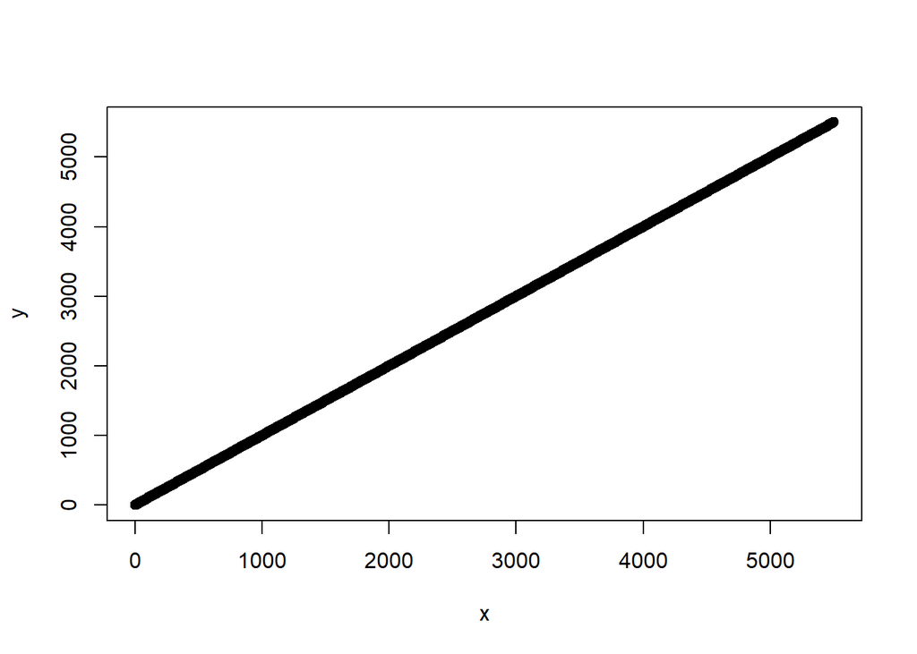

```r
plot(x,y)
```

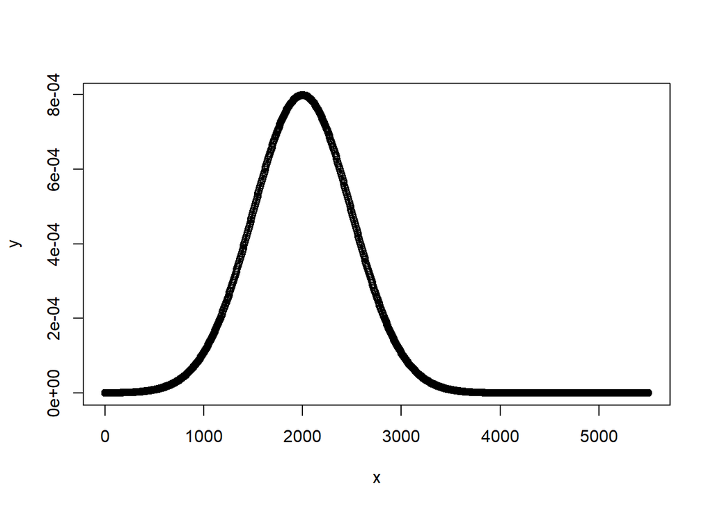

```r
#visualize a normal distribution
y <- dnorm(x = x, mean = 2000, sd = 500)
plot(x,y)
```

```r
#checking class
class(1)
```

```
## [1] "numeric"
```

```r
class("a")
```

```
## [1] "character"
```

```r
b <- "a"
class(b)
```

```
## [1] "character"
```

```r
class(x)
```

```
## [1] "numeric"
```

```r
#check the levels or "unique" values of a factor
rob_listofletters <- c("a", "a", "f", "w", "a", "A", "sequins", "nileseldredge")
class(rob_listofletters)
```

```
## [1] "character"
```

```r
unique(rob_listofletters)
```

```
## [1] "a"             "f"             "w"             "A"
## [5] "sequins"       "nileseldredge"
```

```r
levels(rob_listofletters) #"levels" doesn't work unless the class is "factor" instead of "character"
```

```r
rob_listofletters <- as.factor(c("a", "a", "f", "w", "a", "A", "sequins", "nileseldredge"))
unique(rob_listofletters)
```

```
## [1] a             f             w             A             sequins
## [6] nileseldredge
## Levels: a A f nileseldredge sequins w
```

```r
levels(rob_listofletters)
```

```
## [1] "a"             "A"             "f"             "nileseldredge"
## [5] "sequins"       "w"
```

```r
my_special_list <- levels(rob_listofletters)
class(my_special_list)
```

```
## [1] "character"
```

```r
#R comes with some sample datasets you can see by typing data()
data()
data_iris <- iris #iris is one of the built-in datasets
head(data_iris)
```

|  | Sepal.Length | Sepal.Width | Petal.Length | Petal.Width | Species |
| --- | --- | --- | --- | --- | --- |
| 1 | 5.1 | 3.5 | 1.4 | 0.2 | setosa |
| 2 | 4.9 | 3.0 | 1.4 | 0.2 | setosa |
| 3 | 4.7 | 3.2 | 1.3 | 0.2 | setosa |
| 4 | 4.6 | 3.1 | 1.5 | 0.2 | setosa |
| 5 | 5.0 | 3.6 | 1.4 | 0.2 | setosa |
| 6 | 5.4 | 3.9 | 1.7 | 0.4 | setosa |

```r
names(data_iris)
```

```
## [1] "Sepal.Length" "Sepal.Width"  "Petal.Length" "Petal.Width"  "Species"
```

```r
class(data_iris$Species)
```

```
## [1] "factor"
```

```r
unique(data_iris$Species)
```

```
## [1] setosa     versicolor virginica
## Levels: setosa versicolor virginica
```

```r
levels(data_iris$Species)
```

```
## [1] "setosa"     "versicolor" "virginica"
```

```r
mean(data_iris$Sepal.Length)
```

```
## [1] 5.843333
```

```r
#summarize using aggregate(). We are using functions within functions.
data_iris_sepal <- do.call(data.frame, #"do.call(data.frame," is optional but helps put in good format for downstream processing
  aggregate(Sepal.Length~Species,
    data = data_iris,
    function(x)
    c(mean = mean(x),
    count = length(x),
    SEM = sd(x)/sqrt(length(x)))))
data_iris_summary <- do.call(data.frame,
  aggregate(cbind(Sepal.Length,Sepal.Width)~Species, #we  make use of cbind() within aggregate() to summarize multiple "y"s
    data = data_iris,
    function(x)
    c(mean = mean(x),
    count = length(x),
    SEM = sd(x)/sqrt(length(x)))))

#for demo purposes I am going to add a new factor to the dataset to show how to aggregate by multiple things
newcolumn <- rep(c(letters[1:3]),times=50) #this makes a new column with a bunch of letters
data_iris_new <- cbind(data_iris,newcolumn) #use "cbind()" to combine the columns
data_iris_summary_new <- do.call(data.frame,
  aggregate(cbind(Sepal.Length,Sepal.Width)~Species+newcolumn, #on the right side of the "~", you can list multiple things to summarize by using "+"
    data = data_iris,
    function(x)
    c(mean = mean(x),
    count = length(x),
    SEM = sd(x)/sqrt(length(x)))))
```

```r
#loading with read.csv()
data <- read.csv("data_week1.csv") #notice the first cell has some weird characters, this the file encoding for csvs and we don't want to read it
data <- read.csv("data_week1.csv", fileEncoding = 'UTF-8-BOM')

#installing and loading packages
library(readxl)
#loading with read_excel()
data <- read_excel("data_week1.xlsx", skip = 9,
guess_max = 10000, #guessmax prevents columns with many initial banks being imported as a logical FALSE for not NAs)
na = " ") # you can put a period in the quotes if that is how you code blanks.

#You can load data from googledocs
#library(googlesheets4)
#Data_scouting <- read_sheet("put the URL here", skip = 0)
```